# python_interview

## Python for Coding Interviews - Everything you need to Know

- https://neetcode.io/courses/lessons/python-for-coding-interviews
- Python is dynamically typed (types are determined at runtime -->> no need to define "int x = 0")
- interpreted (line-by-line & no code compile to machine lang)
- can accept multiple assignments
  - a, b = 1, "ball"
- Null in python is **None**

#### variables

```python
# Variables are dynamicly typed
n = 0
print('n =', n)

n = "abc"
print('n =', n)

# Multiple assignments
n, m = 0, "abc"
n, m, z = 0.125, "abc", False

# Increment
n = n + 1 # good
n += 1    # good
# n++       # bad

# None is null (absence of value)
n = 4
n = None
print("n =", n)
```

```
n = 0
n = abc
n = None
```

#### if-elif-else

```python
# If statements don't need parentheses
# or curly braces.
n = 1
if n > 2:
    n -= 1
elif n == 2:
    n *= 2
else:
    n += 2

# Parentheses needed for multi-line conditions.
# and = &&
# or  = ||
n, m = 1, 2
if ((n > 2 and
    n != m) or n == m):
    n += 1
```

#### Loops

```python
n = 2
while n < 5:
    print(n)
    n += 1
print("while is done****")
# Looping from i = 0 to i = 4
for i in range(5):
    print(i)
print("for with range(5) is done****")
# Looping from i = 2 to i = 5
for i in range(2, 6):
    print(i)
print("for with range(2,6) is done****")
# Looping from i = 5 to i = 2
for i in range(5, 1, -1):
    print(i)
print("for with range(5,1,-1) is done****")
```

```
2
3
4
while is done****
0
1
2
3
4
for with range(5) is done****
2
3
4
5
for with range(2,6) is done****
5
4
3
2
for with range(5,1,-1) is done****
```

#### math

```python
# Division is decimal by default *****
print("5 / 2", 5 / 2)

# Double slash rounds down *****
print("5 // 2", 5 // 2)

# CAREFUL: most languages round towards 0 by default
# So negative numbers will round down
print("-3 // 2", -3 // 2)

# A workaround for rounding towards zero
# is to use decimal division and then convert to int.
print("int(-3 / 2)", int(-3 / 2))


# Modding is similar to most languages
print("10 % 3", 10 % 3)

# Except for negative values
print("-10 % 3", -10 % 3)

# To be consistent with other languages modulo
import math
from multiprocessing import heap
print(math.fmod(-10, 3))

# More math helpers
print("floor(3 / 2)", math.floor(3 / 2))
print("ceil(3 / 2)", math.ceil(3 / 2))
print("sqrt(2)", math.sqrt(2))
print("pow(2,3)", math.pow(2, 3))

# Max / Min Int
float("inf")
float("-inf")

# Python numbers are infinite so they never overflow
print(math.pow(2, 200))

# But still less than infinity
print(math.pow(2, 200) < float("inf"))
```

```
5 / 2 2.5
5 // 2 2
-3 // 2 -2
int(-3 / 2) -1
10 % 3 1
-10 % 3 2
-1.0
floor(3 / 2) 1
ceil(3 / 2) 2
sqrt(2) 1.4142135623730951
pow(2,3) 8.0
1.6069380442589903e+60
True
```

#### List (Similar to Arrays)

```python
# Arrays (called lists in python)
arr = [1, 2, 3]
print(arr)

# Can be used as a stack *****
arr.append(4)
arr.append(5)
print(arr)

# removes last element
arr.pop()
print(arr)

# insert value at particular index
# note: this O(n) time operation
arr.insert(1, 7)
print(arr)

# update values
arr[0] = 0
arr[3] = 0
print(arr)

# Initialize arr of size n with default value of 1
n = 5
arr = [1] * n
print(arr)
print(len(arr))

# Careful: -1 is not out of bounds, it's the last value
arr = [1, 2, 3]
print(arr[-1])

# Indexing -2 is the second to last value, etc.
print(arr[-2])

# Sublists (aka slicing)
arr = [1, 2, 3, 4]
print(arr[1:3])

# Similar to for-loop ranges, last index is non-inclusive
print(arr[0:4])

# But no out of bounds error
print(arr[0:10])

# Unpacking ************
a, b, c = [1, 2, 3]
print(a, b, c)

# Be careful though
# a, b = [1, 2, 3]

# Loop through arrays
nums = [1, 2, 3]

# Using index -- this can be adjusted similar to emumerate
for i in range(len(nums)):
    print(nums[i])

# Without index
for n in nums:
    print(n)

# With index and value
for i, n in enumerate(nums):
    print(i, n)

# Loop through multiple arrays simultaneously with unpacking
nums1 = [1, 3, 5]
nums2 = [2, 4, 6]
print("Loop through multiple arrays simultaneously with unpacking")
for n1, n2 in zip(nums1, nums2):
    print(n1, n2)

# Reverse
nums = [1, 2, 3]
nums.reverse()
print(nums)

# Sorting
arr = [5, 4, 7, 3, 8]
arr.sort()
print(arr)

arr.sort(reverse=True)
print(arr)

arr = ["bob", "alice", "jane", "doe"]
arr.sort()
print(arr)

# Custom sort (by length of string)
print("Custom sort (by length of string) for array {}".format(arr)),
arr.sort(key=lambda x: len(x))
print(arr)


# List comprehension
arr = [i for i in range(5)]
print(arr)

# 2-D lists
arr = [[0] * 4 for i in range(4)] # no need if i here ... [[0, 0, 0, 0], [0, 0, 0, 0], [0, 0, 0, 0], [0, 0, 0, 0]]
print(arr)
print(arr[0][0], arr[3][3])

# This won't work
# arr = [[0] * 4] * 4
```

```
[1, 2, 3]
[1, 2, 3, 4, 5]
[1, 2, 3, 4]
[1, 7, 2, 3, 4]
[0, 7, 2, 0, 4]
[1, 1, 1, 1, 1]
5
3
2
[2, 3]
[1, 2, 3, 4]
[1, 2, 3, 4]
1 2 3
1
2
3
1
2
3
0 1
1 2
2 3
Loop through multiple arrays simultaneously with unpacking
1 2
3 4
5 6
[3, 2, 1]
[3, 4, 5, 7, 8]
[8, 7, 5, 4, 3]
['alice', 'bob', 'doe', 'jane']
Custom sort (by length of string) for array ['alice', 'bob', 'doe', 'jane']
['bob', 'doe', 'jane', 'alice']
[0, 1, 2, 3, 4]
[[0, 0, 0, 0], [0, 0, 0, 0], [0, 0, 0, 0], [0, 0, 0, 0]]
0 0
```

#### strings

```python
# Strings are similar to arrays
s = "abc"
print(s[0:2])

# But they are immutable
# s[0] = "A"

# So this creates a new string
s += "def"
print(s)

# Valid numeric strings can be converted
print(int("123") + int("123"))

# And numbers can be converted to strings
print(str(123) + str(123))

# In rare cases you may need the ASCII value of a char
print(ord("a"))
print(ord("b"))

# Combine a list of strings (with an empty string delimitor)
strings = ["ab", "cd", "ef"]
print("".join(strings))
```

```
ab
abcdef
246
123123
97
98
abcdef
```

#### queues

```python
# Queues (double ended queue)
from collections import deque

queue = deque()
queue.append(1)
queue.append(2)
print(queue)

queue.popleft() # unlike list (stacks), we can pop from left with queue
print(queue)

queue.appendleft(1)
print(queue)

queue.pop()
print(queue)
```

```
deque([1, 2])
deque([2])
deque([1, 2])
deque([1])
```

#### hash-sets

```python
# HashSet
mySet = set()

mySet.add(1)
mySet.add(2)
print(mySet)
print(len(mySet))

print(1 in mySet)
print(2 in mySet)
print(3 in mySet)

mySet.remove(2)
print(2 in mySet)

# list to set
print(set([1, 2, 3]))

# Set comprehension
mySet = { i for i in range(5) }
print(mySet)
```

```
{1, 2}
2
True
True
False
False
{1, 2, 3}
{0, 1, 2, 3, 4}
```

#### hasp-maps (aka DICT)

```python
# HashMap (aka dict)
myMap = {}
myMap["alice"] = 88
myMap["bob"] = 77
print(myMap)
print(len(myMap))

myMap["alice"] = 80
print(myMap["alice"])

print("alice" in myMap)
myMap.pop("alice")
print("alice" in myMap)

myMap = { "alice": 90, "bob": 70 }
print(myMap)

# Dict comprehension
myMap = { i: 2*i for i in range(3) }
print(myMap)

# Looping through maps
myMap = { "alice": 90, "bob": 70 }
for key in myMap:
    print(key, myMap[key])

for val in myMap.values():
    print(val)

for key, val in myMap.items():
    print(key, val)
```

#### Tuples

```python
# Tuples are like arrays but immutable
tup = (1, 2, 3)
print(tup)
print(tup[0])
print(tup[-1])

# Can't modify
# tup[0] = 0

# Can be used as key for hash map/set
myMap = { (1,2): 3 }
print(myMap[(1,2)])

mySet = set()
mySet.add((1, 2))
print((1, 2) in mySet)

# Lists can't be keys
# myMap[[3, 4]] = 5
```

#### Functions

```python
def myFunc(n, m):
    return n * m

print(myFunc(3, 4))

# Nested functions have access to outer variables
def outer(a, b):
    c = "c"

    def inner():
        return a + b + c
    return inner()

print(outer("a", "b"))

# Can modify objects but not reassign
# unless using nonlocal keyword
def double(arr, val):
    def helper():
        # Modifying array works
        for i, n in enumerate(arr):
            arr[i] *= 2

        # will only modify val in the helper scope
        # val *= 2

        # this will modify val outside helper scope
        nonlocal val
        val *= 2
    helper()
    print(arr, val)

nums = [1, 2]
val = 3
double(nums, val)
```

#### Classes

```python
class MyClass:
    # Constructor
    def __init__(self, nums):
        # Create member variables
        self.nums = nums
        self.size = len(nums)

    # self key word required as param
    def getLength(self):
        return self.size

    def getDoubleLength(self):
        return 2 * self.getLength()

myObj = MyClass([1, 2, 3])
print(myObj.getLength())
print(myObj.getDoubleLength())
```

```
3
6
```

#### heaps

```python
import heapq

# under the hood are arrays
minHeap = []
heapq.heappush(minHeap, 3)
heapq.heappush(minHeap, 2)
heapq.heappush(minHeap, 4)

# Min is always at index 0
print(minHeap[0])

while len(minHeap):
    print(heapq.heappop(minHeap))

# No max heaps by default, work around is
# to use min heap and multiply by -1 when push & pop.
maxHeap = []
heapq.heappush(maxHeap, -3)
heapq.heappush(maxHeap, -2)
heapq.heappush(maxHeap, -4)

# Max is always at index 0
print(-1 * maxHeap[0])

while len(maxHeap):
    print(-1 * heapq.heappop(maxHeap))

# Build heap from initial values
arr = [2, 1, 8, 4, 5]
heapq.heapify(arr)
while arr:
    print(heapq.heappop(arr))
```

```
2
2
3
4
4
4
3
2
1
2
4
5
8
```

## Python Big-O Notation:

- https://www.youtube.com/watch?v=BgLTDT03QtU

## program to find String in a List

- https://www.geeksforgeeks.org/python-program-to-find-the-string-in-a-list/

```python
# using IN

a = ['Learn', 'Python', 'With', 'GFG']

str_to_find = 'Python'

if str_to_find in a:
    print("String '{}' found!".format(str_to_find))
else:
    print("String '{}' not found!".format(str_to_find))
```

```
String 'Python' found!
```

```python
# using list.index()

a = ['Learn', 'Python', 'with', 'GFG']

try:
    index = a.index('Python')
    print("String found at index", index)
except ValueError:
    print("String not found!")
```

```
String found at index 1
```

```python
# using list comprehension

a = ['Learn', 'Python', 'With', 'GFG']

found = [item for item in a if item == 'Python']
if found:
    print("String found!")
else:
    print("String not found!")
```

```
String found!
```

## program to find duplicates in list

- https://www.geeksforgeeks.org/python-program-print-duplicates-list-integers/

```python
# using set

a = [1, 2, 3, 1, 2, 4, 5, 6, 5]

# Initialize an empty set to store seen elements
s = set()

# List to store duplicates
dup = []

for n in a:
    if n in s:
        dup.append(n) # as set doesn't takes duplicate, it value is present in set => move to dict
    else:
        s.add(n)

print(dup)
```

```
[1, 2, 5]
```

- dict explantion

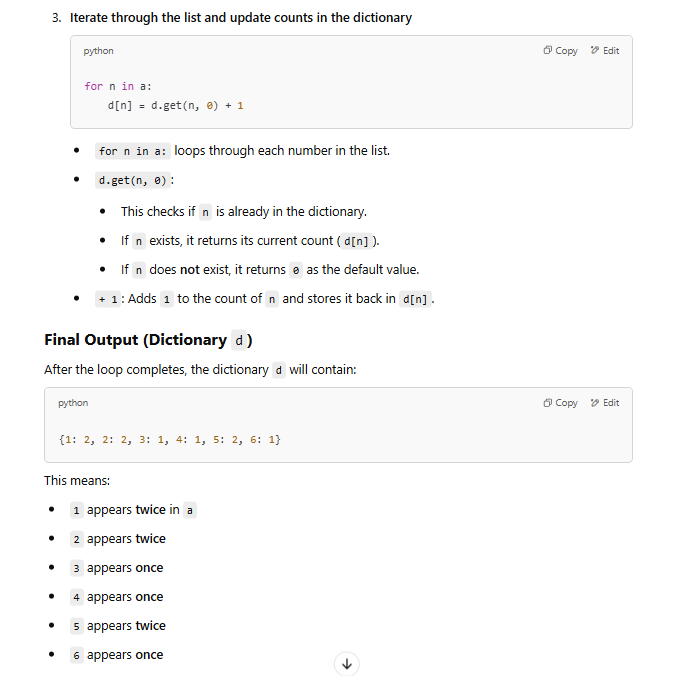

```python
# using dict -- explanation in above image

a = [1, 2, 3, 1, 2, 4, 5, 6, 5]

# Initialize a dictionary to count occurrences
d = {}

for n in a:
    d[n] = d.get(n, 0) + 1

print(d)

# Find duplicates by filtering numbers with count > 1
dup = [n for n, c in d.items() if c > 1]

print(dup)
```

```python
# using FOR loop (not recommended)

a = [1, 2, 3, 1, 2, 4, 5, 6, 5]

# List to store duplicates
dup = []

# Compare each element with other elements
for i in range(len(a)):
    for j in range(i + 1, len(a)):

        # If a duplicate is found and not already recorded
        if a[i] == a[j] and a[i] not in dup:

            # Add to duplicates list
            dup.append(a[i])

print(dup)
```

```
[1, 2, 5]
```

## program to find indexes of all duplicates in list

- https://stackoverflow.com/questions/9542738/find-a-value-in-a-list

```python
# note that if you have duplicates, .index always returns the lowest index
[1,2,3,2].index(2) # => 1
```

```
1
```

```python
# If there are duplicates and you want all the indexes then you can use enumerate() instead
# here we know 2 is duplicate in list
[i for i,val in enumerate([1,2,3,2]) if val==2] # => [1, 3]
```

```
[1, 3]
```

```python
# getting indexes and values

# using set - get duplicates ******************

a = [1, 2, 3, 1, 2, 4, 5, 6, 5]

# Initialize an empty set to store seen elements
s = set()

# List to store duplicates
dup = []

for n in a:
    if n in s:
        dup.append(n) # as set doesn't takes duplicate, it value is present in set => move to dict
    else:
        s.add(n)

print("duplicate items are:", dup)

# to get the indexes
for dup_item in dup:
    [print(i, dup_item) for i,val in enumerate(a) if val==dup_item]
```

```
duplicate items are: [1, 2, 5]
0 1
3 1
1 2
4 2
6 5
8 5
```

## https://medium.com/@seancoyne/what-leetcode-questions-should-a-data-engineer-practice-9ef7cbf0fc11

#### distinct word count

```python
'''
Explanation:

It first splits the sentence into a list of words using the split() method.
This list is then converted to a set, which will eliminate duplicates.
We then return the length of this set, which gives the count of distinct words.
'''

# using set()
def word_count(sentence):
  return len(set(sentence.split()))

word_count("Hello, how are you Are you fine")
```

```
6
```

```python
# using dict()
def word_count_v2(sentence):
  words = sentence.split()
  word_dict = {}
  for word in words:
    word_dict[word] = word_dict.get(word, 0) + 1 # We loop through each word.
                                                 # If a word is not in the dictionary, it gets added with a count of 1.
                                                 # If it already exists, its count is incremented.
  return len(word_dict)

word_count_v2("Hello, how are you Are you fine")
```

```
6
```

#### Average Words Length In a Sentence

```python
def average_word_length(sentence):
  words = sentence.split() # split each word
  total_length = sum(len(word) for word in words) # loop each word > find len > sum of all words len
  return total_length / len(words)

average_word_length("Hello, how are you Are you fine")
```

```
3.5714285714285716
```

#### Average Words Length In a Set

```python
def average_word_length_set(words_set):
  total_length = sum(len(word) for word in words_set)
  return total_length / len(words_set)

average_word_length_set({"Hello", "how", "are", "you", "Are", "you", "fine"}) # note: duplicates in set are removed before computation
```

```
3.5
```

#### palindrome

```python
# Using Strings

def is_palindrome(x: int) -> bool:
  # Convert the integer to a string
  str_x = str(x)
  # Compare the string with its reverse
  return str_x == str_x[::-1]

is_palindrome(12321)
```

```
True
```

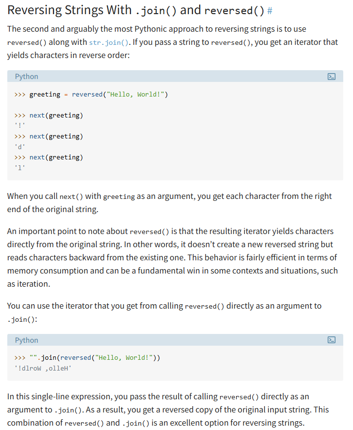

```python
# using built-in methods: join & reverse -- explanation above

string = input("Enter a string: ")
reversed = ''.join(reversed(string))
if string == reversed:
    print("The string is a palindrome")
else:
    print("Not a palindrome")
# Enter a string: 1212
```

#### Balance a List of Integers

> Given a list of ints, balance the list so that each int appears equally in the list. Return a dictionary where the key is the int and the value is the count needed to balance the list.
- First, we need to count how many times each integer appears in the list. We can use Python’s collections.Counter for this purpose.
- Next, we determine the maximum count value. This will be the target count for each integer to balance the list.
- Finally, we construct a dictionary where for each integer, the value is the difference between the target count and its current count. If the difference is zero (i.e., the integer already appears the maximum number of times), we won’t include that integer in the resulting dictionary.

> Example:

> Explantion:
- [1, 1, 2] => {2: 1} ---------->>>>> 2 needs to be added 1 time
- [1, 1, 1, 5, 3, 2, 2] => {5: 2, 3: 2, 2: 1} --------->> 5 needs to be added 2 times. Similarly 2 had to be added 1 time.

```python
def balance_count(lst):
    # Step 1: Count how many times each integer appears in the list
    counts = {}
    for num in lst:
        if num in counts:
            counts[num] += 1
        else:
            counts[num] = 1

    print("Counts: ", counts)

    # Step 2: Determine the maximum count value
    max_count = max(counts.values())

    # Step 3: Construct the result dictionary
    result = {k: max_count - v for k, v in counts.items() if max_count - v > 0}

    return result

balance_count([1,2,2,3,5,1,4,2])
```

```
Counts:  {1: 2, 2: 3, 3: 1, 5: 1, 4: 1}
```

```
{1: 1, 3: 2, 5: 2, 4: 2}
```

#### string rewrite

```python
def encode_string(s: str) -> str:
    # Convert the string to lowercase
    s = s.lower()

    # Create an output string to store the result
    output = []

    # Iterate through the string
    for char in s:
        # Add the character to the output string
        output.append(char)

        # Count the occurrences of the character in the string
        count = s.count(char)

        # Add the count to the output string
        output.append(str(count))

        # Replace all occurrences of the character in the string with an empty string
        # This is to ensure that we don't count this character again in subsequent iterations
        # Eg: 'a' is repeated in string -->> so we don't count it again
        # s = s.replace(char, '')
        # print(s)

    print(output)

    # Convert the list of characters to a string
    return ''.join(output)

encode_string("I am back.")
```

```
['i', '1', ' ', '2', 'a', '2', 'm', '1', ' ', '2', 'b', '1', 'a', '2', 'c', '1', 'k', '1', '.', '1']
```

```
'i1 2a2m1 2b1a2c1k1.1'
```

#### validate IP address

```python
def validate(ip):
    # valid_digit = set('0123456789')
    a = ip.split('.')
    # check if len is 4
    if len(a) != 4:
        return False
    # check every digit
    for x in a:
        if not x.isdigit():
            return False
        i = int(x)
        if i < 0 or i > 255:
            return False
    return True

print(validate("10.1.24.32"))
print(validate("192.168.ip.2"))
```

```
True
False
```

#### Character Existence

```python
def char_exists(word, char):
    return char in word

word = "example"
ch = "a"
print(char_exists(word, ch))  # This will print True
```

```
True
```

#### Fill In Lists

- For given lists, if the value is none replace it with the last non none value, consider the edge case of consecutive Nones.
- examples
  - lst1 = [1,2,3,None, None,4,5]
  - lst2 = [None,8, None]

```python
def listClean(lst):
  result = []
  for i in range( len(lst) ):
    if i == 0:
      result.append(lst[i]) # It just appends the first index element of the input list to the result list.
                            # This is because we don’t have a previous value to compare with or to replace with.

    elif lst[i]==None:
      result.append(result[-1])
    else:
      result.append(lst[i])
  return result

print(listClean([1,2,3,None, None,4,5]))
print(listClean([None,8, None]))
```

```
[1, 2, 3, 3, 3, 4, 5]
[None, 8, 8]
```

#### In One List But Not The Other

- Create a function that returns a list containing mismatched words in two strings.

```python
#check for words that exists in two lists
arr1 = ["this", "is", "my", "test"]
arr2 = ["this", "is", "my", "array"]

def uniqueWords(arr1, arr2):
  result = {}
  for word in arr1:
    result[word]=1
  for word2 in arr2:
    if word2 in result:
      result[word2]=2
    else:
      result[word2]=1
  return [w for w in result if result[w] == 1]

uniqueWords(arr1,arr2)
```

```
['test', 'array']
```

```python
# using sets
arr1 = ["this", "is", "my", "test"]
arr2 = ["this", "is", "my", "array"]

print(list(set(arr1).difference(set(arr2))))
print(list(set(arr2).difference(set(arr1))))

print("Result is: ", list(set(arr1).difference(set(arr2))) + list(set(arr2).difference(set(arr1))))
```

```
['test']
['array']
Result is:  ['test', 'array']
```

#### nth Largest value (in dict)

```python
def nth_largest_key(d, n):
  # Step 1: Convert dictionary values to a list and sort it
  sorted_values = sorted(d.values(), reverse=True)
  # Step 2: Get nth largest value
  nth_largest_value = sorted_values[n-1]
  # Step 3: Return the key corresponding to nth largest value
  for key, value in d.items():
    if value == nth_largest_value:
      return key

# eg: 2nd largest value in dict
nth_largest_key({'a': 1, 'b': 2, 'c': 100, 'd': 30}, 2)
```

```
'd'
```

#### nth Largest value (in list)

```python
def nth_largest_element_in_list(lst, n):
    # Step 1: Convert dictionary values to a list and sort it
    sorted_lst = sorted(lst, reverse=True)
    # Step 2: Get nth largest value
    nth_largest_value = sorted_lst[n-1]
    return nth_largest_value

# 3rd largest element in list [10,23,97,14,51]
nth_largest_element_in_list([10,23,97,14,51], 3)
```

#### Monotonic Arrays

- Given an array of integers, we would like to determine whether the array is monotonic (non-decreasing/non-increasing) or not.
- Examples: 1 2 5 5 8 > true , 9 4 4 2 2 > true, 1 4 6 3 >false, 1 1 1 1 1 1 >true

```python
def is_monotonic(arr):
  increasing = decreasing = True
  for i in range(1, len(arr)):
    if arr[i-1] > arr[i]:
      increasing = False
    if arr[i-1] < arr[i]:
      decreasing = False
  return increasing or decreasing

print(is_monotonic([10,23,97,14,51]))
print(is_monotonic([10,23,27,34,51]))
```

```
False
True
```

## https://medium.com/data-engineer/top-leetcode-problems-for-data-engineers-getting-ready-for-python-interviews-4b6f73c6fb7a

#### two sum

```python
# using hash map

def twoNumberSum(array, targetSum):
    matches = {}
    for number in array:
        match = targetSum - number
        if match in matches:
            return [match, number]
        else:
            matches[number] = True
            print(matches)
    return []

# Test The Code
array = [6, 2, 9, -2, 13, 10]
target = 11

twoNumberSum(array, target)
```

```
{6: True}
{6: True, 2: True}
```

```
[2, 9]
```

#### reverse linked list

```python
# https://stackoverflow.com/a/61723607
# incomplete sol - need to first create a singleLL and then import
'''
reverses single linked list
input: single linked list
output: reversed single linked list
'''
import singleLL

def reverseSll(ll_head):
    # if head of the linked list is empty then nothing to reverse
    if not ll_head:
        return False
    # if only one node, reverse of one node list is the same node
    if not ll_head.next:
        return ll_head
    else:
        second = ll_head.next # get the second node of the list
        ll_head.next = None # detach head node from the rest of the list
        reversedLL = reverseSll(second) # reverse rest of the list
        second.next = ll_head # attach head node to last of the reversed list

        return reversedLL

if __name__ == "__main__":
    sll = singleLL.singleLL()
    for i in range(4):
        sll.insert(i)
    sll.printLL()
    print(sll.head.data)
    print("Reversing single LL")
    n=sll.head
    rsll = reverseSll(sll.head)
    sll.head = rsll
    sll.printLL()
```

#### valid parenthesis

```python
# using stack and dict

def isValid(s: str) -> bool:
    # if input is not even => False
    if len(s) % 2 != 0:
        return False

    # create an empty stack to store results
    stack = []

    # create a dict with matching parenthesis
    dict_parenthesis = {'(' : ')', '[' : ']', '{' : '}'}

    for i in s:
        # if dict item is in stack => append
        # i.e. if exists => append
        if i in dict_parenthesis.keys():
            stack.append(i)
        else:
            # if not exists & empty
            if stack == []:
                return False

            # if not exists but NOT empty
            a = stack.pop()
            if i!= dict_parenthesis[a]:
                return False

    return stack == []

print(isValid('([]}'))
print(isValid('(}{)[]'))
print(isValid('{[()()]}'))
```

```
False
False
True
```

```python
# using stack

# s = "{[()()]}"

s = '({})[]'
st = []

for c in s:

    # Push opening brackets onto the stack
    if c in '({[':
        st.append(c)

    # Check for matching closing bracket
    elif c in ')}]':
        if not st or (c == ')' and st[-1] != '(') or (c == '}' and st[-1] != '{') or (c == ']' and st[-1] != '['):
            print(False)  # Mismatched bracket
            break
        st.pop()  # Pop matched opening bracket

else:
    print(True if not st else False)  # Balanced if stack is empty
```

#### merge two sorted list

```python
# Using sorted() with Concatenation
```

```python
a = [1, 3, 5]
b = [2, 4, 6]

c = sorted(a + b)
print(c)
```

```
[1, 2, 3, 4, 5, 6]
```

```python
# Using heapq.merge()
'''
Explanation:

- heapq.merge(a, b) merges two sorted lists without creating extra copies.
- It returns an iterator, so we convert it into a list.
- This method is memory-efficient and works well for large datasets.
'''

import heapq

a = [1, 3, 5]
b = [2, 4, 6]

c = list(heapq.merge(a, b))
print(c)
```

```
[1, 2, 3, 4, 5, 6]
```

#### best time to buy and sell stock

```python
def max_profit(prices):
    n = len(prices)
    res = 0

    price_buy= 0
    price_sell = 0

    # Explore all possible ways to buy and sell stock
    for i in range(n - 1):
        for j in range(i + 1, n):

            # new code block to get prices
            if (prices[j] - prices[i]) > res:
                price_buy= prices[i]
                price_sell = prices[j]

            res = max(res, prices[j] - prices[i])

    return res, price_buy, price_sell

prices = [7, 10, 1, 3, 6, 9, 2]
print(max_profit(prices))
```

```
(8, 1, 9)
```

```python
class Solution:
    def maxProfitFn(self, prices) -> int:
        n = len(prices)
        res = 0

        # Explore all possible ways to buy and sell stock
        for i in range(n - 1):
            for j in range(i + 1, n):
                res = max(res, prices[j] - prices[i])

        return res

obj = Solution()
prices = [7, 10, 1, 3, 6, 9, 2]
print(obj.maxProfitFn(prices))
```

```
8
```

#### Climbing stairs to reach the top

- https://www.geeksforgeeks.org/count-ways-reach-nth-stair/

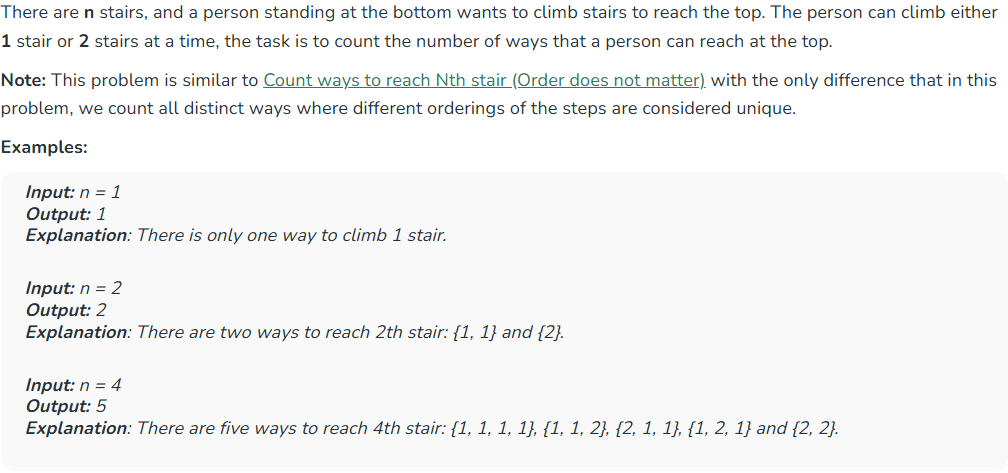

```python
# nth stair using recursion

def countWays(n):

    # Base cases: If there are 0 or 1 stairs,
    # there is only one way to reach the top.
    if n == 0 or n == 1:
        return 1

    return countWays(n - 1) + countWays(n - 2) # The person can climb either 1 stair or 2 stairs at a time

n = 4
print(countWays(n))
```

```
5
```